# Predicting the mass of prehistoric flying animals

## In order to predict the weight of prehistoric birds, we will use **wingspan and mass data from modern bats** to create linear models

```r
library(devtools)
library(rlang)
```

And then install the Bat Wing git hub package using:

```r
pak::pak("oleon12/BatWing")
```

```
ℹ No downloads are needed
```

```
✔ 1 pkg: kept 1 [3.3s]
```

We can load and preview the bat wing data using:

```r
library(BatWing)

data(wing)
head(wing)
```

```
         id ForearmLength Digit5.Length Digit4.Length Digit3.Length Mass
1 ODLAM-011          41.4         63.20         61.70         87.50 15.5
2 ODLAM-010          42.4         64.10         62.60         94.90 17.5
3 ODLAM-012          37.9         54.60         58.20         76.00  9.0
4 ODLAM-014          41.5         58.30         58.95         79.70 16.5
5 ODLAM-016          31.0         28.40         49.90         60.75  7.5
6 ODLAM-018          42.1         59.15         61.90         79.90 15.5
  Wingspan
1      330
2      325
3      295
4      319
5      238
6      331
```

# Finding LSA (lifting surface area)

Use this command to calculate the LSA according to the “BM” and “SS” formulas:

“BM” = Blood and McFarlane 1988  
“SS” = Smith and Starett 1979

“BM”:

LSA = 2* [(FA*V) +1/2(V * III)]

“SS”:

LSA = 2[(FA*V) +1/2*(cos(a)III*IV) +1/2*(sin(a)IV * V)]

{ found in https://github.com/oleon12/BatWing }

```r
LSA <- BatWingArea(x=wing, scale=TRUE, method=c("BM","SS"))
head(LSA$Area)
```

```
                   BM          SS
ODLAM-011 0.010762960 0.011892700
ODLAM-010 0.011518770 0.012604629
ODLAM-012 0.008288280 0.009585018
ODLAM-014 0.009485410 0.010660039
ODLAM-016 0.003486100 0.005107123
ODLAM-018 0.009706515 0.011134029
```

```r
print(head(LSA$Area))
```

```
                   BM          SS
ODLAM-011 0.010762960 0.011892700
ODLAM-010 0.011518770 0.012604629
ODLAM-012 0.008288280 0.009585018
ODLAM-014 0.009485410 0.010660039
ODLAM-016 0.003486100 0.005107123
ODLAM-018 0.009706515 0.011134029
```

{The scale=TRUE function turns the measurements from millimeters and grams to meters and kilograms}

I will merge the Area from the LSA data frame and the mass from the wing dataframe in order to simplify the creation of linear models.

```r
df <- data.frame(
    Area = LSA$Area,   # or whatever your column is actually called
    Mass = wing$Mass/1000
)
```

dividing mass by 1000 converts the units of grams into units of kilograms.

# Creating linear models

I will now create 3 linear models.

The first lm (model1) is created using Mass as a function of the Area as calculated by the Blood and McFarlane formula (1988)  
The second lm (model2) is created using Mass as a function of the Area as calculated by the Smith and Starret formula (1979)

The third lm (model3) is created using Mass as a function of the Wingspan

### Mass ~ Area.BM

```r
model1 <- lm(Mass ~ Area.BM, data = df)
summary(model1)
```

```
Call:
lm(formula = Mass ~ Area.BM, data = df)

Residuals:
      Min        1Q    Median        3Q       Max
-0.006051 -0.002632 -0.001088  0.003460  0.007376

Coefficients:
            Estimate Std. Error t value Pr(>|t|)
(Intercept) 0.002144   0.003390   0.632  0.54482
Area.BM     1.557333   0.306418   5.082  0.00095 ***
---
Signif. codes:  0 '***' 0.001 '**' 0.01 '*' 0.05 '.' 0.1 ' ' 1

Residual standard error: 0.004546 on 8 degrees of freedom
Multiple R-squared:  0.7635,    Adjusted R-squared:  0.734
F-statistic: 25.83 on 1 and 8 DF,  p-value: 0.0009503
```

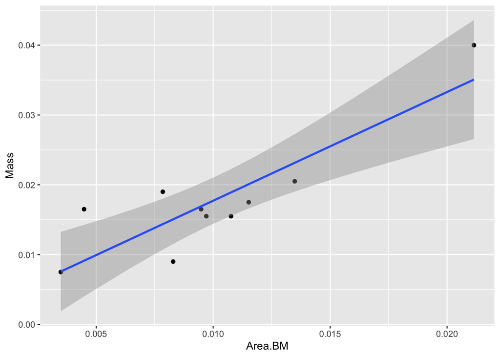

```r
library(ggplot2)

ggplot(df, aes(x = Area.BM, y = Mass)) +
  geom_point() +
  geom_smooth(method = "lm", se = TRUE)
```

### Mass ~ Area.SS

```r
model2 <- lm(Mass ~ Area.SS, data = df)
summary(model2)
```

```
Call:
lm(formula = Mass ~ Area.SS, data = df)

Residuals:
      Min        1Q    Median        3Q       Max
-0.005759 -0.002220 -0.001220  0.003477  0.006952

Coefficients:
            Estimate Std. Error t value Pr(>|t|)
(Intercept) 0.001413   0.003399   0.416 0.688626
Area.SS     1.392434   0.264068   5.273 0.000753 ***
---
Signif. codes:  0 '***' 0.001 '**' 0.01 '*' 0.05 '.' 0.1 ' ' 1

Residual standard error: 0.004419 on 8 degrees of freedom
Multiple R-squared:  0.7766,    Adjusted R-squared:  0.7486
F-statistic:  27.8 on 1 and 8 DF,  p-value: 0.0007525
```

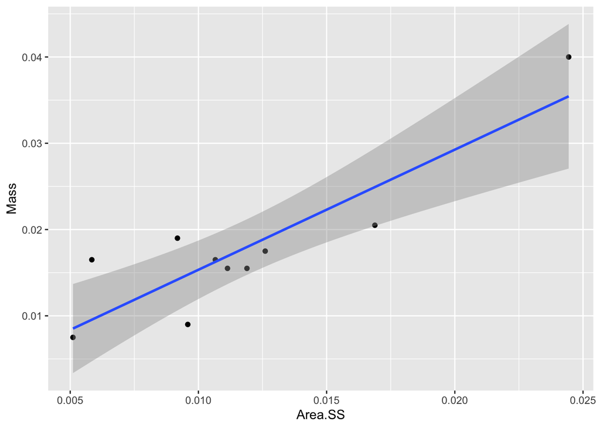

```r
library(ggplot2)

ggplot(df, aes(x = Area.SS, y = Mass)) +
  geom_point() +
  geom_smooth(method = "lm", se = TRUE)
```

### Mass ~ Wingspan

For model 3, we need to make a new columns on the wing df which contains the mass and wingspan in units of m and kg, that way we can better comprehend the data.

```r
wing$Mass_kg <- wing$Mass / 1000
wing$Wingspan_m <- wing$Wingspan / 1000

model3 <- lm(Mass_kg ~ Wingspan_m, data = wing)
summary(model3)
```

```
Call:
lm(formula = Mass_kg ~ Wingspan_m, data = wing)

Residuals:
       Min         1Q     Median         3Q        Max
-0.0065853 -0.0015683  0.0003694  0.0027778  0.0047156

Coefficients:
             Estimate Std. Error t value Pr(>|t|)
(Intercept) -0.017354   0.005765   -3.01 0.016815 *
Wingspan_m   0.104072   0.016704    6.23 0.000251 ***
---
Signif. codes:  0 '***' 0.001 '**' 0.01 '*' 0.05 '.' 0.1 ' ' 1

Residual standard error: 0.003864 on 8 degrees of freedom
Multiple R-squared:  0.8291,    Adjusted R-squared:  0.8078
F-statistic: 38.82 on 1 and 8 DF,  p-value: 0.000251
```

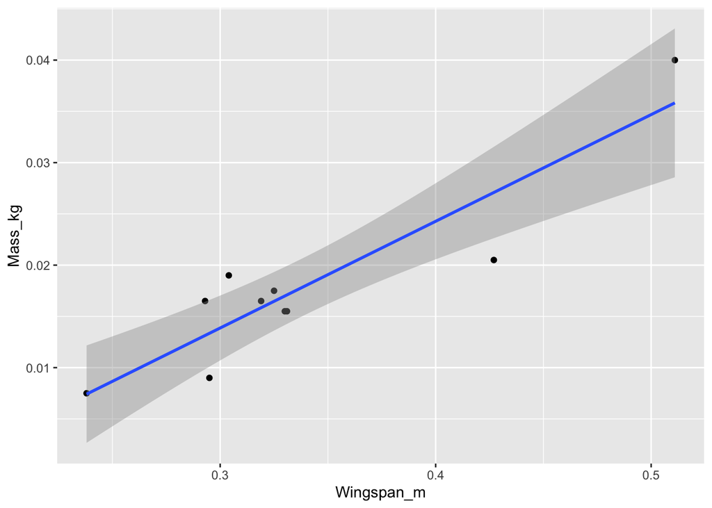

```r
library(ggplot2)

ggplot(wing, aes(x = Wingspan_m, y = Mass_kg)) +
  geom_point() +
  geom_smooth(method = "lm", se = TRUE)
```

**Analysis of linear models:**  
**Model 3**, the one that **Predicts Mass from Wingspan** has the **highest Adjusted R-squared value**, which leads me to believe that this model will yield the highest quality predictions. This is beneficial because it is also the simplest model.

# Prediction of mass based off of wingspan. We will be predicting the mass of the Quetzacoatlus and Pterodactylus dinosaurs

According to https://www.britannica.com/animal/pterodactyl ,

**The wingspan of the Quetzacoatlus** may have been **2 - 11 meters!** this is a very large range, which is **not ideal for mass prediction**, however, we can determine a preliminary range

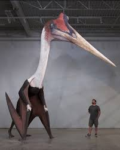

**The wingspan of the Pterodactylus** may have been **0.50 to 1 meter**

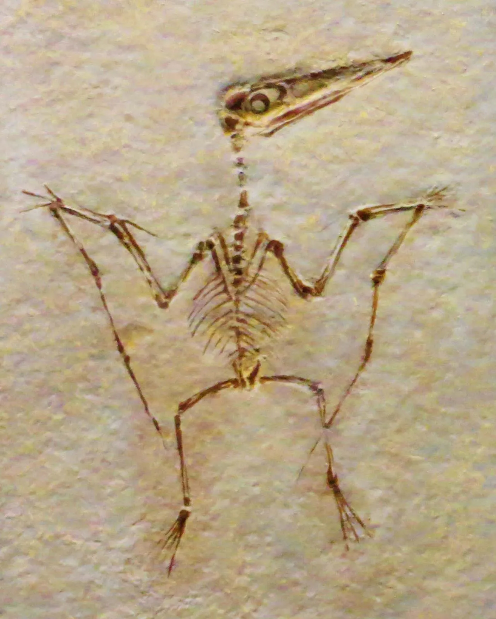

**These mass predictions will not account for factors such as:**

prehistoric air density, size of the head and neck, wingbeat frequency (how many times a wing is pumped during an interval of time), ect.  
**However**, the wingspan data should give us a rough range of mass values, a fine starting point in this analysis.

We will create new dataframes which contain the wingspan length according to brittanica:

Creating predictions for quetzacoatlus:

```r
quetz <- data.frame(Wingspan_m = c(2,11))
predictions_q <- predict(model3, newdata = quetz)
print(predictions_q)
```

```
       1        2
0.190791 1.127441
```

Creating predictions for pterodactylus:

```r
ptero <- data.frame(Wingspan_m = c(0.50,1))
predictions_p <- predict(model3, newdata = ptero)
print(predictions_p)
```

```
         1          2
0.03468256 0.08671869
```

This data suggests that the quetzacoatlus may have weighed between 0.191 - 1.127 kg

This suggests that the pterodactylus may have weighed between 0.034 - 0.087 kg!

**This number does not make any sense. The quetzacoatlus depicted in the picture above is much large than 1.127 kg.**

# What have we learned:

**The relationship between wingspan and mass of a winged creature is not linear**

**Determining the mass of a winged creature is much more complicated than anticipated.**

If we try to use the known wingspan of a bee and compare the known weight of a bee to the predicted weight of a bee, we will find that the predicted weight is in the negative.

```r
bee <- data.frame(Wingspan_m = c(0.018,0.020))
predictions_b <- predict(model3, newdata = bee)
print(predictions_b)
```

```
          1           2
-0.01548027 -0.01527213
```

What this indicates is that our linear model is too inaccurate for all sizes of winged creature.

**This means that the model is very specific to bats.**

# Conclusion:

The weight of a winged creature is **not** linearly dependent on the wingspan of said creature.  
These conclusions are not very satisfying, however, this does tell us that the physics determining the lift of a creature is much more complex than the length of the wings.